# Bootstrapping

November 13, 2017

## Introduction and Agenda

Our discussion today:

- Motivation
- Parametric vs Non-Parametric Methods
- Statitistical Bootstrapping and Associated Use Cases
- Q&A

## Motivation

Consider our estimates of the mean of a population using a sample distribution like the one below.

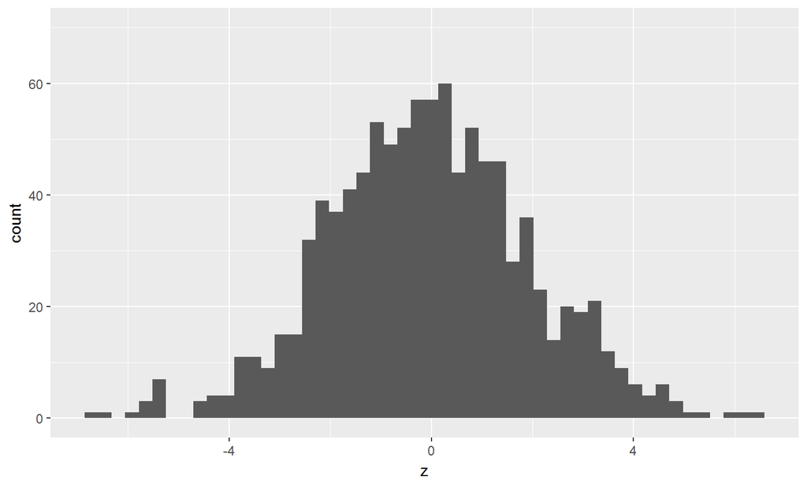

## Motivation

We can make some assumptions about this distribution. It looks like we're centered at a mean around 0, standard deviation is around 2 or 3. Here's an overlay of \(\ N(0,2)\)

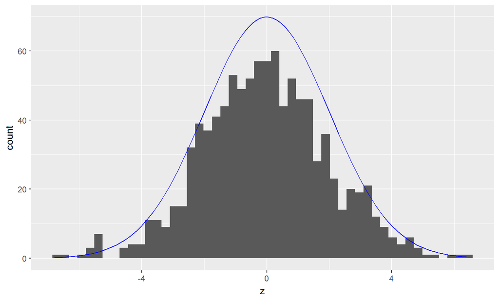

## Motivation

From the previous, we can reasonably use something like a z-test or a t-test to build our confidence intervals around the mean. But what if our data came from an unknown or unknowable probability distribution, or if we have small n?

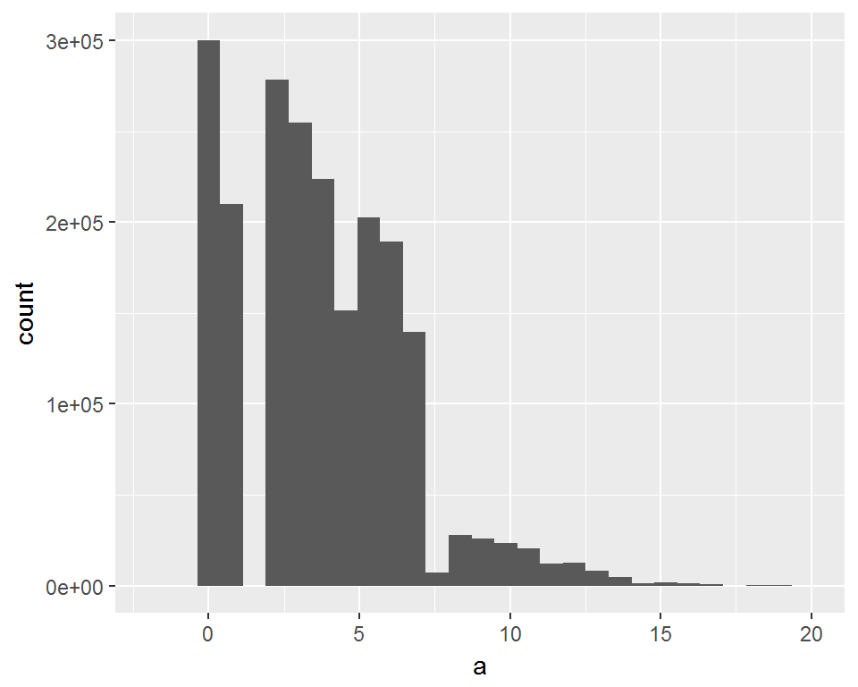

## Parametric vs Non-Parametric Methods

In our first example, where we have strong evidence that the population is normally distributed, we can use a *Parametric* method to estimate the confidence intervals around our sample estimate of \(\mu\).

In our second example of an error distribution, we're forced to consider other methods. Here we can turn to *Non-Parametric* methods. We could use estimates that don't make assumptions about the underlying population distribution (something like a chi-square)

OR, since we have the computational power to do so, we can use a resampling method. This is where bootstrapping comes into play.

## What is Bootstrapping?

In statistics, bootstrapping is a resampling method that helps us understand estimates of population statistics, and can measure our confidence in those estimates. Consider a situation when you want to ask a question about a population statistic (what is the mean of this population), but you do not have the full population, or information about the full population. Perhaps you'd take a sample. In this situation, you should consider using bootstrapping to make inferences about the behavior of the statistic, and your confidence with respect to the statistic.

Statistical Bootstrapping assumes that your sample of the population data mimics the behavior of the population data, meaning for some probability distribution \(\ J\) our sample distribution \(\hat{J}\) is a reasonable approximation of \(\ J\).

## What is the Advantage of Bootstrapping

**Advantages**

The bootstrap is simple. It allows the data to speak for itself, and makes limited assumptions.

**Disadvantages**

Some of the limited assumptions bootstrapping makes are quite important. For example, if samples are not independent, then a major assumption that underlies the bootstrap is violated.

## How Does Bootstrapping Work?

1. Observe a sample from a population
2. Resample (with replacement) from the original sample a number of times
3. Use these bootstrapped replicates to make inferences about the population

## What does this look like?

I'm going to take a random sample of 30 from \(\ N(0,1)\) and then show you the distribution of five resamplings

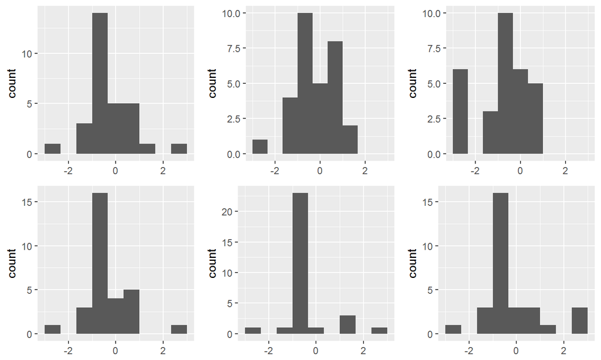

## Applications

- Case Resampling (Monte Carlo or Exact) resamples from a distribution to estimate statistics like the sample mean
- Residual Resampling (this is what we use in our work)
- Smooth bootstrap (attaches random noise to observations in the data)
- Bayesian bootstrap (reweights observations to create new data, and a series of posterior distributions)
- Many others

## Questions?

[figure not shown]